# Study case: the African bush elephant (*Loxodonta africana*)

rcites team

10-08-2018

# Introduction and setup

In [Get started with rcites](https://ibartomeus.github.io/rcites/articles/get_started.html), we explained how to get a token and set it up for general access to the CITES Species+ database. Also, we very briefly introduced to how to code the key features of `rcites`. With this article, we aim to further introduce to the functionality and workflows of `rcites`. For this, we use the African bush elephant (*Loxodonta africana*, hereafter “elephant”) as a case study. The elephant not only is a highly endangered species that is illegally traded globally but also a flagship species of nature conservation and the logo species of CITES.

We start with a basic set up: we load the package and set the token:

```r
library(rcites)
set_token("8QW6Qgh57sBG2k0gtt")
```

# Retrieve the taxon id

In order to access information about the elephant, we first need to retrieve its Species+ taxon identifier. For this, we use the `spp_taxonconcept()` function and the elephant’s scientific name, *Loxodonta africana*, as `query_taxon` argument.

```r
elephant_taxonconcept <- spp_taxonconcept(query_taxon = "Loxodonta africana")
elephant_taxonconcept
```

```
#>  General info - CITES ($general):
#>  --------------------------------
#>      id          full_name        author_year    rank name_status
#>  1 4521 Loxodonta africana (Blumenbach, 1797) SPECIES           A
#>             updated_at active cites_listing
#>  1 2018-07-02 12:15:37   TRUE          I/II
#>
#>  Classification ($higher_taxa):
#>  -------------------------------
#>      id  kingdom   phylum    class       order       family
#>  1 4521 Animalia Chordata Mammalia Proboscidea Elephantidae
#>
#>  Synonyms ($synonyms):
#>  ----------------------
#>      id apply.do.call.rbind..tmp.wch....2..unlist.
#>  1 4521                                      37069
#>  2 4521                         Loxodonta cyclotis
#>  3 4521                           (Matschie, 1900)
#>  4 4521                                    SPECIES
#>
#>  Common names ($common_names):
#>  ------------------------------
#>       id                  name language
#>  1  4521               Olifant       AF
#>  2  4521                   Fel       AR
#>  3  4521                   Fil       AZ
#>  4  4521                  Slon       BE
#>  5  4521                  Slon       BG
#>  6  4521              Elefante       CA
#>  7  4521                  Slon       CS
#>  8  4521     afrikansk elefant       DA
#>  9  4521               Elefant       DA
#>  10 4521 Afrikanischer Elefant       DE
#>  -------truncated-------
#>
#>  Information available: $all_id, $general, $higher_taxa, $accepted_names, $common_names, $synonyms, $cites_listings
```

As the first column of the output shows, the taxon identifier of the elephant is 4521. This `taxon_id` will be used for all next function coding.

Beyond the taxon identifier, the output also provides information about the taxon classification and other names, both synonyms and common names if any, in different languages.

## Map the elephant’s distribution

Before giving more insights into the legislation status of the elephant, we have a look at where the elephant actually occurs naturally. For this, we can access the elephant’s distribution information with the `spp_distributions()` function. Thereafter, we can map the distribution with the help of the `rworldmap` package.

```r
library(rworldmap)

par(las = 1)
elephant_distr <- spp_distributions(taxon_id = "4521", verbose = FALSE)$distributions

map2 <- joinCountryData2Map(elephant_distr,
                            joinCode="ISO2",
                            nameJoinColumn = "iso_code2",
                            nameCountryColumn = "name")
```

```
#>  42 codes from your data successfully matched countries in the map
#>  0 codes from your data failed to match with a country code in the map
#>  201 codes from the map weren't represented in your data
```

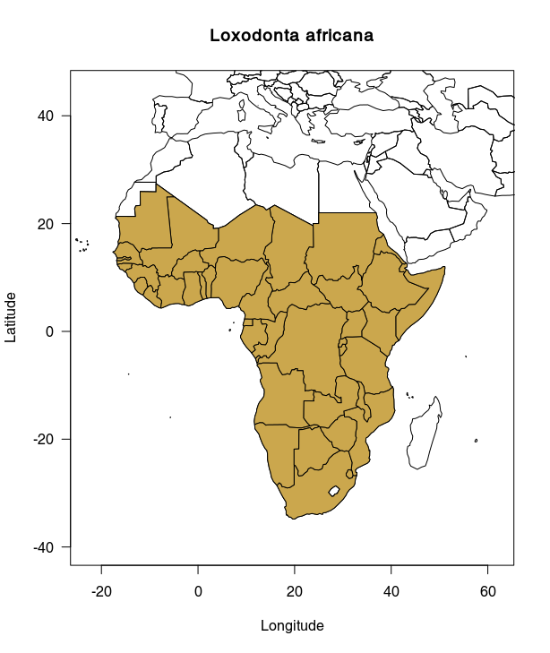

```r
plot(c(-23, 62), c(45, -40),
     type = "n",
     main = "Loxodonta africana",
     xlab = "Longitude",
     ylab = "Latitude")
plot(map2, add = TRUE)
plot(map2[!is.na(map2$iso_code2),], col = "#cba74d", add = TRUE)
```

## Access the legislation status

The functions `spp_cites_legislation()` and `spp_eu_legislation()` provide access to the legislation status information of the elephant.

First, we have a look at the CITES legislation status:

```r
elephant_cites <- spp_cites_legislation(taxon_id = "4521")
```

```
#>  >>> Now processing taxon_id '4521'............ done.
```

```r
elephant_cites
```

```
#>  Cites listings ($cites_listings):
#>  ---------------------------------
#>      id taxon_concept_id is_current appendix change_type effective_at
#>  1 3645             4521       TRUE        I          R+   1990-01-18
#>  2 3666             4521       TRUE       II           +   2007-09-13
#>  3 3665             4521       TRUE        I           +   2007-09-13
#>
#>  Cites quotas ($cites_quotas):
#>  ------------------------------
#>        id taxon_concept_id quota publication_date public_display is_current
#>  1  20604             4521     0       2017-03-06           TRUE       TRUE
#>  2  20586             4521     0       2017-03-06           TRUE       TRUE
#>  3  20695             4521     0       2017-03-06           TRUE       TRUE
#>  4  20696             4521     0       2017-03-06           TRUE       TRUE
#>  5  20697             4521     0       2017-03-06           TRUE       TRUE
```

[output cut: 45 more lines]

We can do the same for the elephant’s legislation status in the European Union:

```r
elephant_eu <- spp_eu_legislation(taxon_id = "4521")
```

```
#>  >>> Now processing taxon_id '4521'............ done.
```

```r
elephant_eu
```

```
#>  EU listings ($eu_listings):
#>  ---------------------------
#>       id taxon_concept_id is_current annex change_type effective_at
#>  1 27801             4521       TRUE     A           +   2017-02-04
#>  2 27868             4521       TRUE     B           +   2017-02-04
#>
#>  EU decisions ($eu_decisions):
#>  ------------------------------
#>        id taxon_concept_id start_date is_current eu_decision_type.name
#>  1  26285             4521 2015-04-09       TRUE              Positive
#>  2  25508             4521 2014-09-03       TRUE              Positive
#>  3   2765             4521 2011-12-02       TRUE                    i)
#>  4  11682             4521 2012-02-23       TRUE              Positive
#>  5  24825             4521 2014-05-28       TRUE              Positive
#>  6  27017             4521 2015-09-15       TRUE              Positive
```

[output cut: 38 more lines]

With the combination of `map2` and the legislation data, one might be able to illustrate the elephant’s trade directions. This and other use examples of the `rcites` data output will be added bit by bit.

## Access the elephant’s Species+ reference data

Last but not least, it is important to identify which references the Species+ information about the elephant is based on. For this, we can access the Species+ reference data with the `spp_references()` function.

```r
elephant_refs <- spp_references(taxon_id = "4521", verbose = FALSE)
elephant_refs
```

```
#>  References ($references):
#>  -------------------------
#>        id                                             citation is_standard
#>  1  10265 Anon. 1978. Red data book: Mammalia. IUC [truncated]       FALSE
#>  2   6344 Barnes, R. F., Agnagna, M., Alers, M. P. [truncated]       FALSE
#>  3  17013 Blanc, J.J., Thouless, C.R., Hart, J.A., [truncated]       FALSE
#>  4   6371 Burton, M. P. 1994. Alternative projecti [truncated]       FALSE
#>  5   6532 Douglas-Hamilton, I. 1987. African Eleph [truncated]       FALSE
#>  6   6534 Douglas-Hamilton, I. 1987. African Eleph [truncated]       FALSE
#>  7   6825 Jackson, P. 1982. Elephants and rhinos i [truncated]       FALSE
#>  8   7224 Meester, J. and Setzer, H. W (eds.) 1974 [truncated]       FALSE
#>  9   7609 Parker, I. and Amin, M. 1983. Ivory cris [truncated]       FALSE
#>  10 19397 Parker, I.S.C. and Martin, E.B. 1982. Ho [truncated]       FALSE
#>  -------truncated-------
```

```r
dim(elephant_refs$references)
```

```
#>  [1] 15  3
```